# QMSS 4063 Assignment 2

Svyatoslav Andriyishen

March 13, 2017

## Task

In this first two parts of the exercise, I want you to explore the key variables of AirBnB use, the locations of AirBnB places, and some (potential) indications on how it impacts the rental market. In the third part, I want you to explore whether or not we can find a relationship between the location of subway stations and location, type, and features of AirBnB places. In each task description, I ask you to provide specific visualizations or data analyses, but please include some written explanations as well to situate the visualizations you provide. Do not directly include any code in the rendered output when presenting your results.

### 1. Overall Location

**Question:** Provide a map to show where in New York City AirBnB listings are located. Provide a second map in which you summarize the density of these listings and highlight the hotspots for AirBnB locations. Make sure to annotate a few hotspots on the map.

Map of AirBnB locations:

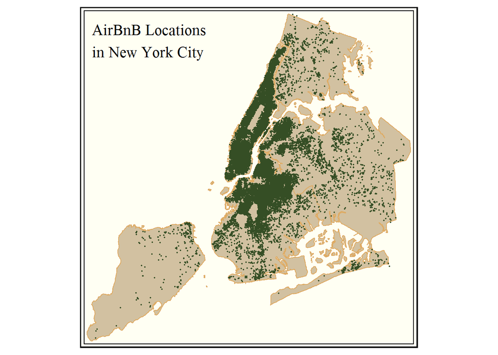

Heatmap of AirBnB locations:

[figure not shown]

**Discussion:** I used `tmap` package for one plot, and `ggplot2` and `ggmap` for another to practice using both. These are simple plots, so I did not overcomplicate things with too many annotations and unnecessary additions. Although on the first map, we have trouble telling how many AirBnB listings there are at each neighborhood due to the 40,000+ listings covering most of Manhattan and Brooklyn, we can tell distinct hotspots of AirBnB activity on the second map. I chose to highlight the two biggest hotspots in East Village and Williamsburg.

### 2. Renting out your appartment vs. permanent rentals

**Question:** An Airbnb host can set up a calendar for their listing so that it is only available for a few days or weeks a year. Other listings are available all year round (except for when it is already booked). Entire homes or apartments highly available and rented frequently year-round to tourists probably don’t have the owner present, are illegal, and more importantly, are displacing New Yorkers.

Choose a combination of *both non-map and map graphs* to explore where in NYC listings are available sporadically vs. year-round. Make sure to highlight the neighborhoods where most listings appear to be permanent or semi-permanent rentals. Try to estimate the average monthly income from such rentals.

Use these and other variables to provide some information about how such permanent rentals differ from sporadic rentals in a concise format (i.e. try to combine summary information and plots in a smart way). Feel free to use summary statistics, map, and/or non-map graphical displays.

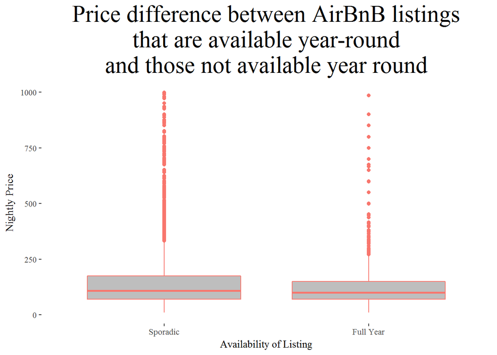

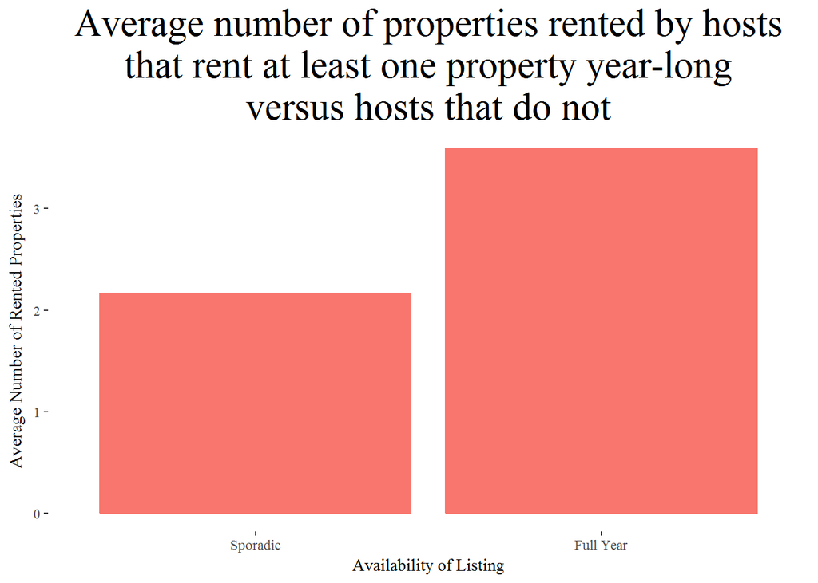

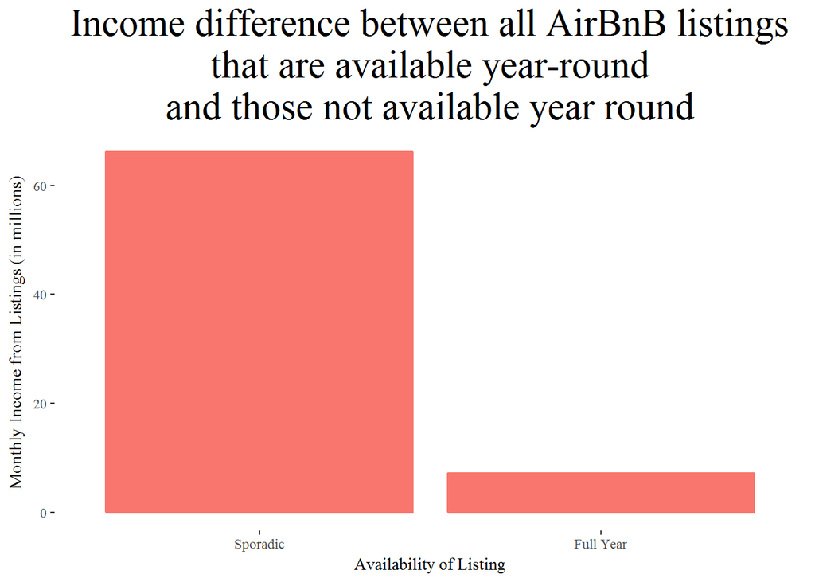

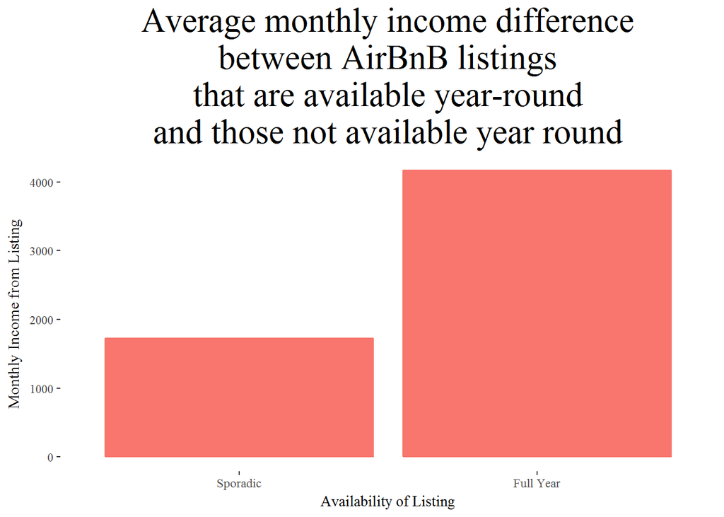

**Discussion:** There doesn’t seem to be much difference in nightly price for an AirBnB listing that is rented out year-round versus one that is rented out only sporadically. Similarly, there is no difference in ratings (plot not shown due to repetitive nature of information) and the heatmap of locations below shows that the concentrations of both types of listings are in the same regions, although there are far fewer year-round listings. However, hosts that rent at least one property year-round, tend to rent more properties on average. Although the larger share of total income from AirBnB listings is coming from sporadic rentals, due to the higher number of them, the year-long rental income is not small (above 5 million). Moreover, the potential mean monthly income from year-long rentals is twice higher than that for sporadic rentals, at around four thousand dollars, making it a lucrative business for a scrupulous host.

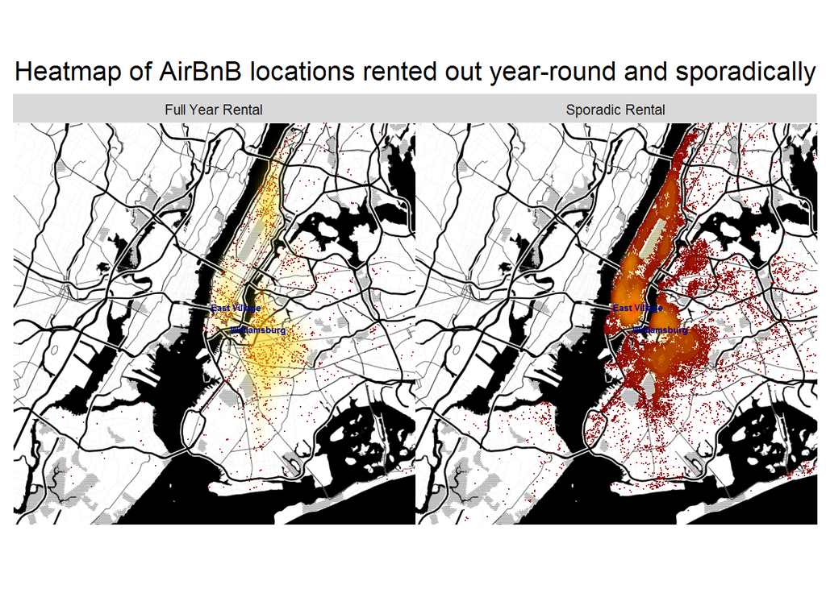

### 3. AirBnB and Subway Access

**Question:** Explore how the location, type, and features of AirBnB listings are related to subway access. For this part, *select a single neighborhood* that lends itself to such an analysis (i.e. has multiple subway stations, different types of AirBnB listings etc.). If you feel ambitious you can complement this with an analysis of the entire city or an entire borough, but don’t get bogged down in analyzing 40,000 listings; focus on a single neighborhood.

You should decide what are some interesting questions and patterns to explore and map here. But please make sure to incorporate the following pieces of analysis:

- Use the information about the location of subway stations and AirBnB listings to calculate distances from each listing to the next (nearest) subway.
- Calculate (and display) how many listings are in different perimeters around a subway station. Make sure to map the subway stations (and lines) to give the reader an idea of what you are doing.
- Explore whether the price of listings is related to having access to the subway nearby. Try to control for some other obvious determinants of price: how many people the space sleeps, whether itâs an entire property or a private room, the type of property (apartment, boat, house, loft), and the number of reviews. Display and describe your findings.

[figure not shown]

**Discussion:** I took 250 meters distance between an AirBnB listing and a subway entrace to mean “close” for this map.

[figure not shown]

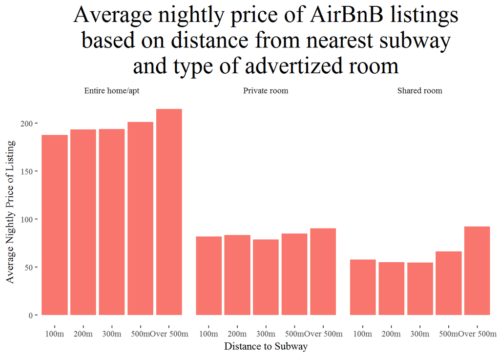

**Discussion:** I tried plotting the last plot using `accommodates`, `property_type`, `bedrooms`, `review_scores_rating`, and other variables, but all of the results were very similar, so I chose not to include them. It seems that access to subway entrances has a slight negative impact on the nightly price of AirBnB listings in Williamsburg. This may be because listings farther away from the subway could be coastline properties with nice views and might, therefore, cost more.

#### Project Book

For this week, I broke down some of the code I used to explore the data and some initial (mostly unsuccessful for my needs) methods I tried for various parts of the exercise. I do think that we need *much more* instruction on subsetting data, as that is the actual timesink in these assignments and not the actual data visualization.

I also messed up on setting CRS coordinates and had to submit this assignment a day late. My original code for question 3 ran, but I modified the data loading code earlier in the markdown file in a way that my sp objects switched from projected to unprojected and rgeos functions stopped running. I tried very hard to figure it out, but could not do it in time on Monday, March 13. Over the next day, I set the CRS to an EPSG format measured in meters for New York City, and that seemed to fix the problem. I apologize for being late.

Some initial data exploration:

```r
str(airbnb)
str(ny_boro, max.level = 2)
str(wlms_stops)
```

Some initial research on combining spatial layers and sorting data:

Condensing dataframes research:

```r
by_neighborhood <- airbnb %>%
  group_by(neighbourhood) %>%
  summarise(avg_avail = mean(availability_365, na.rm = TRUE),
            avg_price = mean(price_2, na.rm = TRUE),
            counts = n())
by_neighborhood <- as.data.frame(by_neighborhood)
summary(by_neighborhood)
```

```
##  neighbourhood        avg_avail       avg_price          counts
##  Length:200         Min.   :  0.0   Min.   : 38.00   Min.   :   1.0
##  Class :character   1st Qu.:142.8   1st Qu.: 78.16   1st Qu.:   6.0
##  Mode  :character   Median :189.0   Median :100.20   Median :  20.5
##                     Mean   :198.8   Mean   :123.20   Mean   : 201.1
##                     3rd Qu.:243.5   3rd Qu.:146.84   3rd Qu.: 117.0
##                     Max.   :365.0   Max.   :700.00   Max.   :6019.0
```

```r
ny_neigh@data <- data.frame(ny_neigh@data, by_neighborhood[match(ny_neigh@data[,"neighbourhood"], by_neighborhood[,"neighbourhood"]),])

ny_neigh@data$counts
```

```
##   [1]   NA    8    8   NA    2   NA   24   20    8    6   NA   NA   NA  894
##  [15]    6   32   68  117   NA   NA   24   NA 2199   NA   NA   10   44    3
##  [29]   NA  219   24   NA   NA   25   NA   39   11  110   26   NA 1665   NA
##  [43]   NA  292    8   57  198    2   NA   NA  823   21   NA   NA    2  709
##  [57]   NA   53    6 1122   NA    2   25   24   13   52    2    1   NA   NA
##  [71]   31    2   NA  113    7   20  143  835   NA    4    1   82   NA  147
##  [85]  989    6    6   NA   NA   NA  340  565  175   33   NA  134  115   84
##  [99]  353   NA    3    4   NA    4   NA   NA   NA    9   28  115   NA    3
## [113]    1  797  358    5 1400 1313   12   NA   NA   NA    4    4   NA    2
## [127]  117  124  194    2   NA   10  358   NA   41   NA    9  203  161    3
## [141] 1009   11    9  332   87   11    2    6    3   35    5   17    6    1
## [155]  276   NA   NA   NA    4    2    5    3   NA  261   NA  628   17    8
## [169]   NA   NA   NA   21    9   NA  305    7   47   36   54   NA  246    7
## [183]   22   NA   56    3   NA   NA   NA   NA   NA   NA   NA  101    9   10
## [197]   NA   NA   13   NA   11   29   15   NA  203    6  186   NA    4    2
## [211]    2   12  117   NA    5   92   NA   14 1226 1531  109   12  741   17
## [225]    2   24    6  662   NA    3   12 3327   NA
```

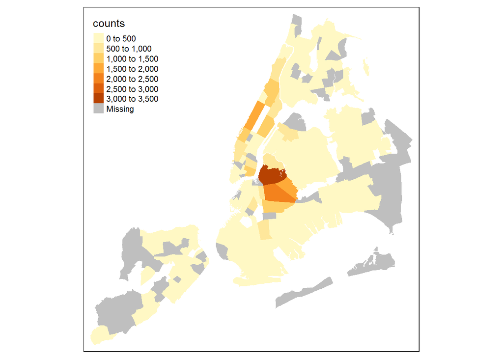

```r
tm_shape(ny_neigh) +
  tm_fill(col = "counts")
```

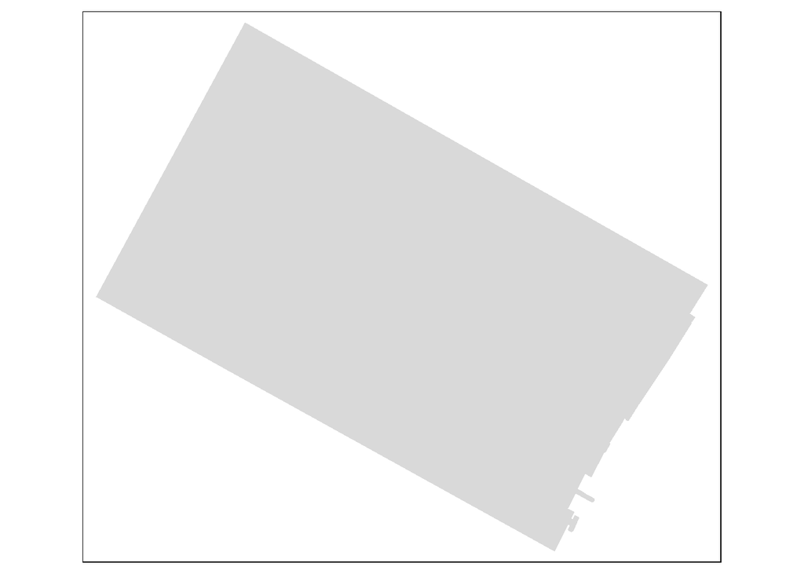

```r
tm_shape(ny_neigh[138,]) +
  tm_fill()
```

Exploration for question 2:

```r
# Recode data
summary(airbnb$availability_365)

abnb_fullyear <- airbnb[which(airbnb$availability_365 == 365),]
summary(abnb_fullyear$availability_365)

abnb_notfullyear <- airbnb[which(airbnb$availability_365 != 365),]
summary(abnb_notfullyear$availability_365)

airbnb$price_2 = as.numeric(gsub("\\$", "", airbnb$price))
summary(airbnb$price_2)

airbnb$fullyear <- ifelse(airbnb$availability_365 == 365,  1, 0)
sum(airbnb$fullyear)

# Graph availability vs price information
ggplot(data = airbnb, aes(x = as.factor(airbnb$availability_365 == 365), y = price_2,
                          col = as.factor(airbnb$availability_365 == 365) == 1)) +
  geom_boxplot(fill = "grey") +
  scale_x_discrete(labels=c("Not Full Year","Full Year")) +
  labs(x = "Availability of Listing",
       y = "Nightly Price",
       title = "Price difference between AirBnB listings\nthat are available year-round\nand those not available year round") +
  ggthemes::theme_tufte() +
  theme(legend.position = "none",
        plot.title = element_text(hjust = 0.5, size = 24))

ggplot(data = airbnb, aes(x = as.factor(airbnb$availability_365 == 365), y = price_2*availability_365/12/10^6,
                          col = as.factor(airbnb$availability_365 == 365) == 1)) +
  geom_bar(fill = "grey", stat = "identity") +
  scale_x_discrete(labels=c("Not Full Year","Full Year")) +
  labs(x = "Availability of Listing",
       y = "Monthly Income from Listings (in millions)",
       title = "Income difference between all AirBnB listings\nthat are available year-round\nand those not available year round") +
  ggthemes::theme_tufte() +
  theme(legend.position = "none",
        plot.title = element_text(hjust = 0.5, size = 24))

ggplot(data = airbnb, aes(x = as.factor(airbnb$availability_365 == 365), y = price_2*availability_365/12,
                          col = as.factor(airbnb$availability_365 == 365) == 1)) +
  stat_summary(fun.y="mean", geom="bar", fill = "#F8766D") +
  scale_x_discrete(labels=c("Not Full Year","Full Year")) +
  labs(x = "Availability of Listing",
       y = "Monthly Income from Listing",
       title = "Average monthly income difference\nbetween AirBnB listings\nthat are available year-round\nand those not available year round") +
  ggthemes::theme_tufte() +
  theme(legend.position = "none",
        plot.title = element_text(hjust = 0.5, size = 24))

# Found base ggplot colors to match in the last plot by using ggplot_build()$data #F8766D


# Create a map of hotspots
ggplot() +
  geom_polygon(data = ny_boro, aes(x = long, y = lat, group = group), fill = "darkgrey") +
  geom_point(data = abnb_fullyear, aes(x = longitude, y = latitude), col = I("darkred"), size = .0001, size = 3) +
  stat_density2d(aes(x = longitude,y = latitude,
                 fill = ..level.., alpha = ..level..),
                 data = airbnb, geom = 'polygon', bins = 12) +
  scale_fill_gradient2(low = "white", mid="yellow", high = "red") +
  scale_alpha(range = c(0.00, 0.5)) + theme(legend.position = "none") +
  labs(title = "",
       x = "", y = "") +
  theme(plot.title = element_text(hjust = 0.5, size = 20),
        axis.line=element_blank(),
        axis.text=element_blank(),
        axis.ticks=element_blank(),
        axis.title=element_blank(),
        panel.background=element_blank(),
        panel.border=element_blank(),
        panel.grid=element_blank(),
        panel.margin=unit(0, "lines"),
        plot.background=element_blank())
```

Identifying neighborhoods:

```r
# pick one neighborhood
ny_neigh$neighbourhood
```

```
##   [1] Bayswater                  City Island
##   [3] Allerton                   Ditmars Steinway
##   [5] Gerritsen Beach            Port Ivory
##   [7] Soundview                  Ozone Park
##   [9] Fordham                    Whitestone
##  [11] Arden Heights              Arrochar
##  [13] Arverne                    Astoria
##  [15] Bath Beach                 Bayside
##  [17] Battery Park City          Bay Ridge
##  [19] Bay Terrace                Bay Terrace, Staten Island
##  [21] Baychester                 Bayswater
##  [23] Bedford-Stuyvesant         Belle Harbor
##  [25] Bellerose                  Belmont
##  [27] Bensonhurst                Bergen Beach
##  [29] Bloomfield                 Boerum Hill
```

[output cut: 103 more lines]

```r
# select Williamsburg
Williamsburg_n <- 232
```

Spatial join code research:

```r
summary(ny_neigh, max.level = 2)
```

```
## Object of class SpatialPolygonsDataFrame
## Coordinates:
##         min       max
## x -74.25559 -73.70782
## y  40.49613  40.91553
## Is projected: FALSE
## proj4string :
## [+proj=longlat +datum=NAD83 +ellps=GRS80 +towgs84=0,0,0]
## Data attributes:
##        neighbourhood    neighbourhood_group neighbourhood.1
##  Bayswater    :  2   Bronx        :50       Length:233
##  City Island  :  2   Brooklyn     :48       Class :character
##  Howard Beach :  2   Manhattan    :32       Mode  :character
##  Allerton     :  1   Queens       :55
##  Arden Heights:  1   Staten Island:48
##  Arrochar     :  1
##  (Other)      :224
##    avg_avail       avg_price          counts
##  Min.   :  0.0   Min.   : 38.00   Min.   :   1.0
##  1st Qu.:144.4   1st Qu.: 78.07   1st Qu.:   6.0
##  Median :189.2   Median : 99.09   Median :  21.5
##  Mean   :199.0   Mean   :119.54   Mean   : 190.8
##  3rd Qu.:243.5   3rd Qu.:134.95   3rd Qu.: 126.5
##  Max.   :365.0   Max.   :700.00   Max.   :3327.0
##  NA's   :73      NA's   :73       NA's   :73
```

```r
summary(airbnb.df)
```

[output not shown]

[output cut: 203 more lines]

```
##  Length:40227                     Min.   : 1.000
##  Class :character                 1st Qu.: 1.000
##  Mode  :character                 Median : 1.000
##                                   Mean   : 1.711
##                                   3rd Qu.: 2.000
##                                   Max.   :33.000
##
##  reviews_per_month
##  Min.   : 0.010
##  1st Qu.: 0.330
##  Median : 0.920
##  Mean   : 1.422
##  3rd Qu.: 2.080
##  Max.   :14.560
##  NA's   :9077
```

```r
Murray_Hill <- ny_neigh[138,]
summary(Murray_Hill, max.level = 2)
```

```
## Object of class SpatialPolygonsDataFrame
## Coordinates:
##         min       max
## x -73.98296 -73.96792
## y  40.74304  40.75280
## Is projected: FALSE
## proj4string :
## [+proj=longlat +datum=NAD83 +ellps=GRS80 +towgs84=0,0,0]
## Data attributes:
##        neighbourhood    neighbourhood_group neighbourhood.1
##  Murray Hill  :1     Bronx        :0        Length:1
##  Allerton     :0     Brooklyn     :0        Class :character
##  Arden Heights:0     Manhattan    :1        Mode  :character
##  Arrochar     :0     Queens       :0
##  Arverne      :0     Staten Island:0
##  Astoria      :0
##  (Other)      :0
##    avg_avail     avg_price         counts
##  Min.   :128   Min.   :183.1   Min.   :203
##  1st Qu.:128   1st Qu.:183.1   1st Qu.:203
##  Median :128   Median :183.1   Median :203
##  Mean   :128   Mean   :183.1   Mean   :203
##  3rd Qu.:128   3rd Qu.:183.1   3rd Qu.:203
##  Max.   :128   Max.   :183.1   Max.   :203
##
```

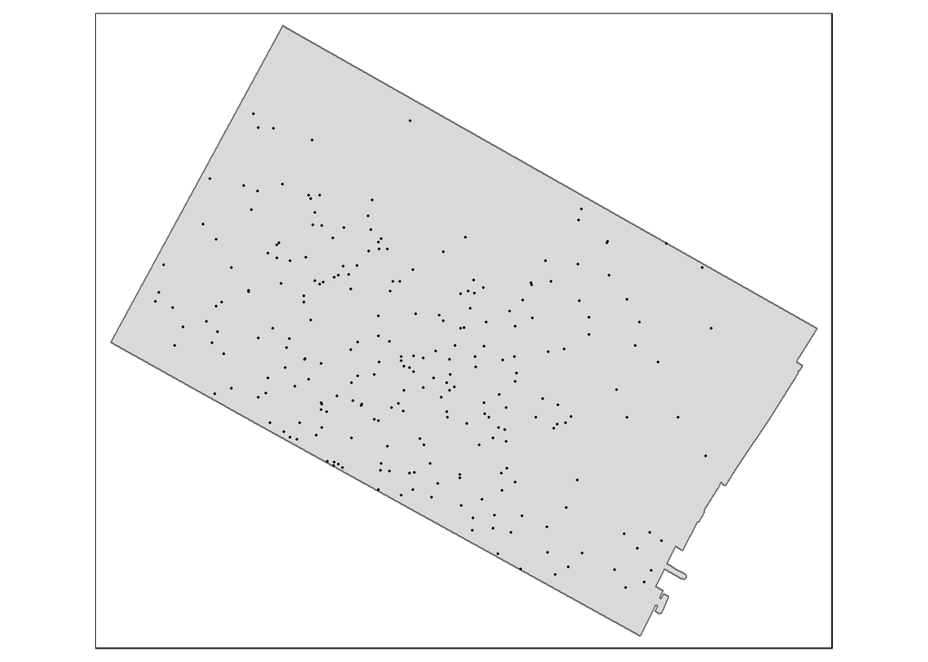

```r
Murray_Hill <- spTransform(Murray_Hill, CRS(proj4string(ny_boro)))
airbnb.df <- spTransform(airbnb.df, CRS(proj4string(ny_boro)))
airbnb_murray <- airbnb.df[Murray_Hill,]

tm_shape(ny_neigh[138,]) +
  tm_borders() + tm_fill() +
tm_shape(airbnb_murray) +
  tm_dots()
```

Find EPSG code for NAD83:

```r
EPSG <-make_EPSG() # create data frame of available EPSG codes
EPSG[grepl("NAD83$", EPSG$note), ] # "+init=epsg:4269"
```

```
##     code    note                                prj4
## 198 4269 # NAD83 +proj=longlat +datum=NAD83 +no_defs
```